# Optimisation de la gestion des données d'un boutique.

## Importation des librairies

```python
import pandas as pd
import numpy as np
import seaborn as sns

import warnings
warnings.filterwarnings('ignore')
```

## Importation des dataset

```python
erp = pd.read_excel('erp.xlsx')
web = pd.read_excel('web.xlsx')

liaison = pd.read_excel('liaison.xlsx')
```

## Exploratory Data Analysis

Cette partie contient l'analyse des 3 dataset.

### ERP

ERP (825 lignes) contient:

```
-les références produits
-l'indication de vente ou non en ligne
-les prix de vente des produits
-l'état de stock en quantité
-l'état de stock par mention (vide ou contenant du stock)
```

#### Shape

```python
es = erp.shape
print("ERP est de dimensions", es)
```

```
ERP est de dimensions (825, 5)
```

#### Info (Columns Names / NaN Count / Dtypes)

```python
erp.info()
```

```
<class 'pandas.core.frame.DataFrame'>
RangeIndex: 825 entries, 0 to 824
Data columns (total 5 columns):
 #   Column          Non-Null Count  Dtype
---  ------          --------------  -----
 0   product_id      825 non-null    int64
 1   onsale_web      825 non-null    int64
 2   price           825 non-null    float64
 3   stock_quantity  825 non-null    int64
 4   stock_status    825 non-null    object
dtypes: float64(1), int64(3), object(1)
memory usage: 32.4+ KB
```

#### Stats

```python
erp.describe()
```

|  | product_id | onsale_web | price | stock_quantity |
| --- | --- | --- | --- | --- |
| count | 825.000000 | 825.000000 | 825.000000 | 825.000000 |
| mean | 5162.597576 | 0.869091 | 32.415636 | 26.496970 |
| std | 902.644635 | 0.337506 | 26.795849 | 45.892422 |
| min | 3847.000000 | 0.000000 | 5.200000 | 0.000000 |
| 25% | 4348.000000 | 1.000000 | 14.600000 | 1.000000 |
| 50% | 4907.000000 | 1.000000 | 24.400000 | 11.000000 |
| 75% | 5805.000000 | 1.000000 | 42.000000 | 34.000000 |
| max | 7338.000000 | 1.000000 | 225.000000 | 578.000000 |

#### Est-ce qu'il y a des valeurs importantes qui sont manquantes ?

Il n'y a pas de valeurs manquantes dans ERP.

#### Est-ce qu'il y a des valeurs manquantes qu'il faudrait combler ou supprimer (leurs absence n'apporte pas d'informations) ?

Il n'y a pas de valeurs manquantes dans ERP.

#### Est-ce qu'il y a des valeurs uniques ?

```python
erp.nunique()
```

```
product_id        825
onsale_web          2
price             381
stock_quantity    128
stock_status        2
dtype: int64
```

#### Quelles sont les deux types de valeurs dans "onsale_web" et dans "stock_status" et leurs répartitions ?

```python
vcow = erp["onsale_web"].value_counts()
print(vcow)

vcss = erp["stock_status"].value_counts()
print(vcss)
```

```
1    717
0    108
Name: onsale_web, dtype: int64
instock       638
outofstock    187
Name: stock_status, dtype: int64
```

#### Quelle est la variance des données ?

La variance mesure, la variance des valeurs existant pour une colonne.

Exemple dans la colonne "onsale_web" il n'y a que deux valeurs --> 0 ou 1, la variance de cette variable est donc faible.

A contrario il y a un grand nombre de valeurs dans la colonne "product_id", donc la variance de cette colonne est grande.

Plus la variance est grande, plus le nombre est grand.

```python
erp.var()
```

```
product_id        814767.337858
onsale_web             0.113910
price                718.017534
stock_quantity      2106.114372
dtype: float64
```

#### Comment sont distribuées les valeurs ?

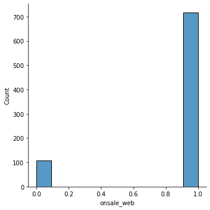

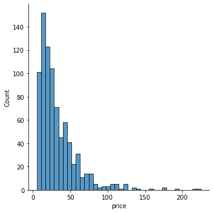

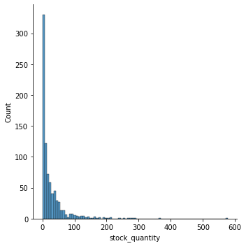

```python
sns.displot(data=erp, x="onsale_web")
sns.displot(data=erp, x="price")
sns.displot(data=erp, x="stock_quantity")
```

#### Est-ce qu'il y a des outliers ?

```python
numericals = erp.select_dtypes(include=np.number)
numericals.drop(["product_id", "onsale_web"], axis = 1, inplace = True)

for feature in numericals:
    print(feature.upper())
    smallest = numericals[feature].min()
    print("The smallest value is", smallest)
    highest = numericals[feature].max()
    print("The highest value is", highest)
    median = numericals[feature].median()
    print("The median value is", median)
    mode =  numericals[feature].mode()
    print("The mode value is", mode)
    q1 = numericals[feature].quantile(.25)
    print("Q1 is", q1)
    q3 = numericals[feature].quantile(.75)
    print("Q3 is", q3)
    iqr = q3 - q1
    print("IQR is", iqr)
    lower_range = q1 - (1.5 * iqr)
    print("Lower range is", lower_range)
    upper_range = q3 + (1.5 * iqr)
    print("Upper range is", upper_range)
    lo = numericals.loc[numericals[feature] < lower_range]
    #No lower range outliers found
    uo = numericals.loc[numericals[feature] > upper_range]
```

```
PRICE
The smallest value is 5.2
The highest value is 225.0
The median value is 24.4
The mode value is 0    45.0
dtype: float64
Q1 is 14.6
Q3 is 42.0
IQR is 27.4
Lower range is -26.499999999999993
Upper range is 83.1
STOCK_QUANTITY
The smallest value is 0
The highest value is 578
The median value is 11.0
The mode value is 0    0
dtype: int64
Q1 is 1.0
Q3 is 34.0
IQR is 33.0
Lower range is -48.5
Upper range is 83.5
```

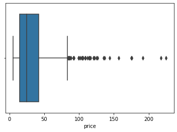

```python
sns.boxplot(data=erp, x="price")
```

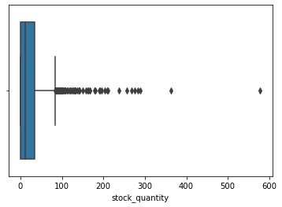

```python
sns.boxplot(data=erp, x="stock_quantity")
```

#### Les outliers nous donne t-il des infos ?

L'on peut constater que pour "price" il y a des outliers allant dans des valeurs très haute et très loin de du Q3 qui est de 42. Il y a une grande variété de prix.

L'on peut constater que pour "stock_quantity" il y a des outliers allant dans des valeurs très haute et très loin de du Q3 qui est de 34. Il y a une grande variété de quantité.

#### Quelles sont les colonnes qu'il est important de garder et de supprimer ?

Il faut toutes les garder.

#### Unicité de la clé primaire

Une clé primaire (composite ou non) permet de garantir à chaque lignes d'être unique.

Donc si mes clés primaires sont bien unique je ne peux pas avoir de lignes en doubles.

Il faut donc que je test si pour l'entièreté d'une ligne il y a ou non des doublons.

Il faut que je trouve quel est ou quels sont les éléments qui composent ma clé primaire.

```python
print("Il y a", erp.duplicated().sum(), "lignes dupliquées.")

print("Il y a", erp["product_id"].duplicated().sum(), "'product_id' dupliqués.")
```

```
Il y a 0 lignes dupliquées.
Il y a 0 'product_id' dupliqués.
```

Je peux composer ma pk de seulement "product_id" car c'est un identifiant unique pour chaque produit.

Je ne peux pas composer ma pk de seulement "onsale_web" car il n'y a que deux valeurs possibles.

Je ne peux pas composer ma pk de seulement "price" car un même prix peu exister pour plein de produits.

Je ne peux pas composer ma pk de seulement "stock_quantity" car une même quantité peu exister pour plein de produits.

Je ne peux pas composer ma pk de seulement "stock_status" car un même statut peu exister pour plein de produits.

La combinaison de chaque colonne créer une ligne unique, mais chaque valeurs des différentes colonnes sauf "product_id" peuvent pour un même produit changer. Et deux produits peuvent avoir la même combinaisons sauf pour la valeur de la colonne "product_id". Pa exemple un produit peut-être retirer ou ajouter des ventes en lignes, ou bien sa quantité en stock peut changer... Mais sont identifiants lui restera unique car il est le seul déterminant du produits, comme un numéro de SS.

*Ma clé primaire est donc composé de "product_id".*

#### Récapitualtif pour le dataset ERP

ERP (825 lignes) contient:

```
-les références produits
-l'indication de vente ou non en ligne
-les prix de vente des produits
-l'état de stock en quantité
-l'état de stock par mention (vide ou contenant du stock)
```

Il est de dimension (825,5).

Il n'a aucune valeur manquante.

Ses valeurs sont numériques, sauf "stock_status" qui est une string.

Le prix le plus haut est de 225, le plus bas est de 5.20 et 75% des prix sont entre 5.20 et 42.

Il n'y a aucune valeur unique, ni de valeurs innapropriées.

La majorité des produits sont commercialisés en lignes, à savoir 717.

La variable onsale_web ayant juste deux valeurs est représentée par une distribution "Bernoulli".

Les variables "price" et "stock_quantity" sont asymétriques.

Le stock le plus haut est de 578, le plus bas est de 0 et 75% des quantitées de stocks sont entre 0 et 34.

Il n'y a pas de colonne inutile.

Ma clé primaire est composée de "product_id".

### WEB

WEB (1513 lignes) (Infos sur les produits commercialisés en lignes) contient:

```
-les noms des produits
-Les descriptions du produits
-le nombre de ventes (depuis sa mise en ligne)
```

#### Shape

```python
ws = web.shape
print("WEB est de dimensions", ws)
```

```
WEB est de dimensions (1513, 28)
```

#### Infos (Columns Names / NaN Count / Dtypes)

```python
web.info()
```

```
<class 'pandas.core.frame.DataFrame'>
RangeIndex: 1513 entries, 0 to 1512
Data columns (total 28 columns):
 #   Column                 Non-Null Count  Dtype
---  ------                 --------------  -----
 0   sku                    1428 non-null   object
 1   virtual                1513 non-null   int64
 2   downloadable           1513 non-null   int64
 3   rating_count           1513 non-null   int64
 4   average_rating         1430 non-null   float64
 5   total_sales            1430 non-null   float64
 6   tax_status             716 non-null    object
 7   tax_class              0 non-null      float64
 8   post_author            1430 non-null   float64
 9   post_date              1430 non-null   datetime64[ns]
```

[output cut: 20 more lines]

```python
pd.set_option("display.max_rows", None)
web
```

|  | sku | virtual | downloadable | rating_count | average_rating | total_sales | tax_status | tax_class | post_author | post_date | ... | post_name | post_modified | post_modified_gmt | post_content_filtered | post_parent | guid | menu_order | post_type | post_mime_type | comment_count |
| --- | --- | --- | --- | --- | --- | --- | --- | --- | --- | --- | --- | --- | --- | --- | --- | --- | --- | --- | --- | --- | --- |
| 0 | bon-cadeau-25-euros | 0 | 0 | 0 | 0.0 | 10.0 | taxable | NaN | 1.0 | 2018-06-01 13:53:46 | ... | bon-cadeau-de-25-euros | 2018-06-01 14:13:57 | 2018-06-01 12:13:57 | NaN | 0.0 | https://www.bottle-neck.fr/?post_type=product&... | 0.0 | product | NaN | 0.0 |
| 1 | 15298 | 0 | 0 | 0 | 0.0 | 6.0 | taxable | NaN | 2.0 | 2018-02-08 12:58:52 | ... | pierre-jean-villa-saint-joseph-preface-2018 | 2019-12-30 09:30:29 | 2019-12-30 08:30:29 | NaN | 0.0 | https://www.bottle-neck.fr/?post_type=product&... | 0.0 | product | NaN | 0.0 |
| 2 | 15296 | 0 | 0 | 0 | 0.0 | 0.0 | taxable | NaN | 2.0 | 2018-02-08 13:49:41 | ... | pierre-jean-villa-saint-joseph-tilde-2017 | 2019-12-21 09:00:17 | 2019-12-21 08:00:17 | NaN | 0.0 | https://www.bottle-neck.fr/?post_type=product&... | 0.0 | product | NaN | 0.0 |
| 3 | 15300 | 0 | 0 | 0 | 0.0 | 0.0 | taxable | NaN | 2.0 | 2018-02-08 14:08:36 | ... | pierre-jean-villa-croze-hermitage-accroche-coe... | 2020-06-26 18:15:03 | 2020-06-26 16:15:03 | NaN | 0.0 | https://www.bottle-neck.fr/?post_type=product&... | 0.0 | product | NaN | 0.0 |
| 4 | 19814 | 0 | 0 | 0 | 0.0 | 3.0 | taxable | NaN | 2.0 | 2018-02-09 14:01:05 | ... | pierre-jean-villa-igp-gamine-2018 | 2020-01-04 16:36:01 | 2020-01-04 15:36:01 | NaN | 0.0 | https://www.bottle-neck.fr/?post_type=product&... | 0.0 | product | NaN | 0.0 |
| 5 | 19815 | 0 | 0 | 0 | 0.0 | 0.0 | taxable | NaN | 2.0 | 2018-02-12 09:04:37 | ... | pierre-jean-villa-cote-rotie-carmina-2017 | 2020-01-04 16:36:10 | 2020-01-04 15:36:10 | NaN | 0.0 | https://www.bottle-neck.fr/?post_type=product&... | 0.0 | product | NaN | 0.0 |
| 6 | 15303 | 0 | 0 | 0 | 0.0 | 0.0 | taxable | NaN | 2.0 | 2018-02-12 09:13:35 | ... | pierre-jean-villa-saint-joseph-saut-ange-2018 | 2019-11-02 13:25:07 | 2019-11-02 12:25:07 | NaN | 0.0 | https://www.bottle-neck.fr/?post_type=product&... | 0.0 | product | NaN | 0.0 |
| 7 | 14975 | 0 | 0 | 0 | 0.0 | 0.0 | taxable | NaN | 2.0 | 2018-02-12 09:45:14 | ... | pierre-gaillard-condrieu-2018 | 2020-08-14 18:15:02 | 2020-08-14 16:15:02 | NaN | 0.0 | https://www.bottle-neck.fr/?post_type=product&... | 0.0 | product | NaN | 0.0 |
| 8 | 16042 | 0 | 0 | 0 | 0.0 | 7.0 | taxable | NaN | 2.0 | 2018-02-12 09:54:27 | ... | pierre-gaillard-cornas-2017 | 2020-08-14 10:15:02 | 2020-08-14 08:15:02 | NaN | 0.0 | https://www.bottle-neck.fr/?post_type=product&... | 0.0 | product | NaN | 0.0 |
| 9 | 14980 | 0 | 0 | 0 | 0.0 | 3.0 | taxable | NaN | 2.0 | 2018-02-12 10:03:05 | ... | pierre-gaillard-cote-rotie-esprit-blond-2017 | 2020-08-24 14:00:03 | 2020-08-24 12:00:03 | NaN | 0.0 | https://www.bottle-neck.fr/?post_type=product&... | 0.0 | product | NaN | 0.0 |
| 10 | 16041 | 0 | 0 | 0 | 0.0 | 14.0 | taxable | NaN | 2.0 | 2018-02-12 10:09:03 | ... | pierre-gaillard-cote-rotie-2018 | 2020-08-03 09:55:03 | 2020-08-03 07:55:03 | NaN | 0.0 | https://www.bottle-neck.fr/?post_type=product&... | 0.0 | product | NaN | 0.0 |
| 11 | 15269 | 0 | 0 | 0 | 0.0 | 6.0 | taxable | NaN | 2.0 | 2018-02-12 10:16:27 | ... | pierre-gaillard-cote-rotie-rose-pourpre-2017 | 2020-08-24 14:00:03 | 2020-08-24 12:00:03 | NaN | 0.0 | https://www.bottle-neck.fr/?post_type=product&... | 0.0 | product | NaN | 0.0 |
| 12 | 14977 | 0 | 0 | 0 | 0.0 | 0.0 | taxable | NaN | 2.0 | 2018-02-12 10:28:30 | ... | pierre-gaillard-gendrines-2018 | 2020-08-27 09:30:07 | 2020-08-27 07:30:07 | NaN | 0.0 | https://www.bottle-neck.fr/?post_type=product&... | 0.0 | product | NaN | 0.0 |
| 13 | 16044 | 0 | 0 | 0 | 0.0 | 7.0 | taxable | NaN | 2.0 | 2018-02-12 10:34:08 | ... | pierre-gaillard-saint-joseph-cuminaille-2018 | 2020-08-14 17:45:03 | 2020-08-14 15:45:03 | NaN | 0.0 | https://www.bottle-neck.fr/?post_type=product&... | 0.0 | product | NaN | 0.0 |
| 14 | 16043 | 0 | 0 | 0 | 0.0 | 1.0 | taxable | NaN | 2.0 | 2018-02-12 10:41:11 | ... | pierre-gaillard-saint-joseph-2018 | 2020-08-26 14:05:02 | 2020-08-26 12:05:02 | NaN | 0.0 | https://www.bottle-neck.fr/?post_type=product&... | 0.0 | product | NaN | 0.0 |
| 15 | 16449 | 0 | 0 | 0 | 0.0 | 6.0 | taxable | NaN | 2.0 | 2018-02-12 10:50:59 | ... | pierre-gaillard-saint-joseph-blanc-2019 | 2020-08-24 09:30:15 | 2020-08-24 07:30:15 | NaN | 0.0 | https://www.bottle-neck.fr/?post_type=product&... | 0.0 | product | NaN | 0.0 |
| 16 | 16045 | 0 | 0 | 0 | 0.0 | 6.0 | taxable | NaN | 2.0 | 2018-02-12 10:58:41 | ... | pierre-gaillard-syrah-terre-mandrin-2018 | 2020-08-27 17:15:02 | 2020-08-27 15:15:02 | NaN | 0.0 | https://www.bottle-neck.fr/?post_type=product&... | 0.0 | product | NaN | 0.0 |
| 17 | 16030 | 0 | 0 | 0 | 0.0 | 6.0 | taxable | NaN | 2.0 | 2018-02-12 11:06:11 | ... | mont-olivet-chateauneuf-pape-blanc-2019 | 2020-08-03 09:55:03 | 2020-08-03 07:55:03 | NaN | 0.0 | https://www.bottle-neck.fr/?post_type=product&... | 0.0 | product | NaN | 0.0 |
| 18 | 13127 | 0 | 0 | 0 | 0.0 | 23.0 | taxable | NaN | 2.0 | 2018-02-12 11:18:33 | ... | clos-du-mont-olivet-chateauneuf-du-pape-2012 | 2020-08-24 18:25:02 | 2020-08-24 16:25:02 | NaN | 0.0 | https://www.bottle-neck.fr/?post_type=product&... | 0.0 | product | NaN | 0.0 |
| 19 | 19816 | 0 | 0 | 0 | 0.0 | 10.0 | taxable | NaN | 2.0 | 2018-02-12 11:25:39 | ... | clos-du-mont-olivet-chateauneuf-du-pape-papet-... | 2020-06-09 15:41:44 | 2020-06-09 13:41:44 | NaN | 0.0 | https://www.bottle-neck.fr/?post_type=product&... | 0.0 | product | NaN | 0.0 |
| 20 | 16029 | 0 | 0 | 0 | 0.0 | 10.0 | taxable | NaN | 2.0 | 2018-02-12 11:38:55 | ... | clos-du-mont-olivet-cotes-du-rhone-vieilles-vi... | 2020-08-01 09:35:04 | 2020-08-01 07:35:04 | NaN | 0.0 | https://www.bottle-neck.fr/?post_type=product&... | 0.0 | product | NaN | 0.0 |
| 21 | 16039 | 0 | 0 | 0 | 0.0 | 18.0 | taxable | NaN | 2.0 | 2018-02-12 11:56:27 | ... | mourgues-galets-dores-2019 | 2020-08-25 15:45:02 | 2020-08-25 13:45:02 | NaN | 0.0 | https://www.bottle-neck.fr/?post_type=product&... | 0.0 | product | NaN | 0.0 |
| 22 | 16318 | 0 | 0 | 0 | 0.0 | 11.0 | taxable | NaN | 2.0 | 2018-02-12 12:07:23 | ... | mourgues-du-gres-costieres-de-nimes-galets-rou... | 2020-08-25 15:45:02 | 2020-08-25 13:45:02 | NaN | 0.0 | https://www.bottle-neck.fr/?post_type=product&... | 0.0 | product | NaN | 0.0 |
| 23 | 16275 | 0 | 0 | 0 | 0.0 | 7.0 | taxable | NaN | 2.0 | 2018-02-12 12:12:28 | ... | mourgues-du-gres-costieres-de-nimes-galets-ros... | 2020-08-27 09:30:16 | 2020-08-27 07:30:16 | NaN | 0.0 | https://www.bottle-neck.fr/?post_type=product&... | 0.0 | product | NaN | 0.0 |
| 24 | 16498 | 0 | 0 | 0 | 0.0 | 9.0 | taxable | NaN | 2.0 | 2018-02-12 12:41:06 | ... | mourgues-du-gres-costieres-de-nimes-argence-ro... | 2020-08-25 11:15:03 | 2020-08-25 09:15:03 | NaN | 0.0 | https://www.bottle-neck.fr/?post_type=product&... | 0.0 | product | NaN | 0.0 |
| 25 | 16320 | 0 | 0 | 0 | 0.0 | 3.0 | taxable | NaN | 2.0 | 2018-02-12 12:49:29 | ... | mourgues-du-gres-costieres-de-nimes-terre-darg... | 2020-08-25 11:15:03 | 2020-08-25 09:15:03 | NaN | 0.0 | https://www.bottle-neck.fr/?post_type=product&... | 0.0 | product | NaN | 0.0 |
| 26 | 16319 | 0 | 0 | 0 | 0.0 | 3.0 | taxable | NaN | 2.0 | 2018-02-12 12:56:54 | ... | mourgues-du-gres-terres-feu-2017 | 2020-08-21 11:25:03 | 2020-08-21 09:25:03 | NaN | 0.0 | https://www.bottle-neck.fr/?post_type=product&... | 0.0 | product | NaN | 0.0 |
| 27 | 15966 | 0 | 0 | 0 | 0.0 | 3.0 | taxable | NaN | 2.0 | 2018-02-12 13:08:24 | ... | oratoire-reserve-seigneurs-rouge-2017 | 2020-08-25 10:25:02 | 2020-08-25 08:25:02 | NaN | 0.0 | https://www.bottle-neck.fr/?post_type=product&... | 0.0 | product | NaN | 0.0 |
| 28 | 15022 | 0 | 0 | 0 | 0.0 | 0.0 | taxable | NaN | 2.0 | 2018-02-12 13:14:22 | ... | oratoire-saint-martin-cairanne-douyes-2016 | 2020-08-27 18:45:02 | 2020-08-27 16:45:02 | NaN | 0.0 | https://www.bottle-neck.fr/?post_type=product&... | 0.0 | product | NaN | 0.0 |
| 29 | 15967 | 0 | 0 | 0 | 0.0 | 20.0 | taxable | NaN | 2.0 | 2018-02-12 13:17:53 | ... | oratoire-saint-martin-cairanne-haut-coustias-2016 | 2020-08-14 18:35:02 | 2020-08-14 16:35:02 | NaN | 0.0 | https://www.bottle-neck.fr/?post_type=product&... | 0.0 | product | NaN | 0.0 |

[output cut: 1483 more lines]

1513 rows × 28 columns

```python
pd.set_option("display.max_rows", None)
nn = web[web.sku.isnull()]
nn
```

|  | sku | virtual | downloadable | rating_count | average_rating | total_sales | tax_status | tax_class | post_author | post_date | ... | post_name | post_modified | post_modified_gmt | post_content_filtered | post_parent | guid | menu_order | post_type | post_mime_type | comment_count |
| --- | --- | --- | --- | --- | --- | --- | --- | --- | --- | --- | --- | --- | --- | --- | --- | --- | --- | --- | --- | --- | --- |
| 178 | NaN | 0 | 0 | 0 | NaN | NaN | NaN | NaN | NaN | NaT | ... | NaN | NaT | NaT | NaN | NaN | NaN | NaN | NaN | NaN | NaN |
| 179 | NaN | 0 | 0 | 0 | NaN | NaN | NaN | NaN | NaN | NaT | ... | NaN | NaT | NaT | NaN | NaN | NaN | NaN | NaN | NaN | NaN |
| 227 | NaN | 0 | 0 | 0 | NaN | NaN | NaN | NaN | NaN | NaT | ... | NaN | NaT | NaT | NaN | NaN | NaN | NaN | NaN | NaN | NaN |
| 230 | NaN | 0 | 0 | 0 | NaN | NaN | NaN | NaN | NaN | NaT | ... | NaN | NaT | NaT | NaN | NaN | NaN | NaN | NaN | NaN | NaN |
| 231 | NaN | 0 | 0 | 0 | NaN | NaN | NaN | NaN | NaN | NaT | ... | NaN | NaT | NaT | NaN | NaN | NaN | NaN | NaN | NaN | NaN |
| 233 | NaN | 0 | 0 | 0 | NaN | NaN | NaN | NaN | NaN | NaT | ... | NaN | NaT | NaT | NaN | NaN | NaN | NaN | NaN | NaN | NaN |
| 237 | NaN | 0 | 0 | 0 | NaN | NaN | NaN | NaN | NaN | NaT | ... | NaN | NaT | NaT | NaN | NaN | NaN | NaN | NaN | NaN | NaN |
| 283 | NaN | 0 | 0 | 0 | NaN | NaN | NaN | NaN | NaN | NaT | ... | NaN | NaT | NaT | NaN | NaN | NaN | NaN | NaN | NaN | NaN |
| 309 | NaN | 0 | 0 | 0 | NaN | NaN | NaN | NaN | NaN | NaT | ... | NaN | NaT | NaT | NaN | NaN | NaN | NaN | NaN | NaN | NaN |
| 310 | NaN | 0 | 0 | 0 | NaN | NaN | NaN | NaN | NaN | NaT | ... | NaN | NaT | NaT | NaN | NaN | NaN | NaN | NaN | NaN | NaN |
| 311 | NaN | 0 | 0 | 0 | NaN | NaN | NaN | NaN | NaN | NaT | ... | NaN | NaT | NaT | NaN | NaN | NaN | NaN | NaN | NaN | NaN |
| 312 | NaN | 0 | 0 | 0 | NaN | NaN | NaN | NaN | NaN | NaT | ... | NaN | NaT | NaT | NaN | NaN | NaN | NaN | NaN | NaN | NaN |
| 313 | NaN | 0 | 0 | 0 | NaN | NaN | NaN | NaN | NaN | NaT | ... | NaN | NaT | NaT | NaN | NaN | NaN | NaN | NaN | NaN | NaN |
| 331 | NaN | 0 | 0 | 0 | NaN | NaN | NaN | NaN | NaN | NaT | ... | NaN | NaT | NaT | NaN | NaN | NaN | NaN | NaN | NaN | NaN |
| 343 | NaN | 0 | 0 | 0 | NaN | NaN | NaN | NaN | NaN | NaT | ... | NaN | NaT | NaT | NaN | NaN | NaN | NaN | NaN | NaN | NaN |
| 346 | NaN | 0 | 0 | 0 | NaN | NaN | NaN | NaN | NaN | NaT | ... | NaN | NaT | NaT | NaN | NaN | NaN | NaN | NaN | NaN | NaN |
| 374 | NaN | 0 | 0 | 0 | NaN | NaN | NaN | NaN | NaN | NaT | ... | NaN | NaT | NaT | NaN | NaN | NaN | NaN | NaN | NaN | NaN |
| 384 | NaN | 0 | 0 | 0 | NaN | NaN | NaN | NaN | NaN | NaT | ... | NaN | NaT | NaT | NaN | NaN | NaN | NaN | NaN | NaN | NaN |
| 404 | NaN | 0 | 0 | 0 | NaN | NaN | NaN | NaN | NaN | NaT | ... | NaN | NaT | NaT | NaN | NaN | NaN | NaN | NaN | NaN | NaN |
| 435 | NaN | 0 | 0 | 0 | NaN | NaN | NaN | NaN | NaN | NaT | ... | NaN | NaT | NaT | NaN | NaN | NaN | NaN | NaN | NaN | NaN |
| 455 | NaN | 0 | 0 | 0 | NaN | NaN | NaN | NaN | NaN | NaT | ... | NaN | NaT | NaT | NaN | NaN | NaN | NaN | NaN | NaN | NaN |
| 457 | NaN | 0 | 0 | 0 | NaN | NaN | NaN | NaN | NaN | NaT | ... | NaN | NaT | NaT | NaN | NaN | NaN | NaN | NaN | NaN | NaN |
| 470 | NaN | 0 | 0 | 0 | 0.0 | 0.0 | taxable | NaN | 2.0 | 2018-07-31 12:07:23 | ... | pierre-jean-villa-cote-rotie-fongeant-2017 | 2019-11-02 13:24:15 | 2019-11-02 12:24:15 | NaN | 0.0 | https://www.bottle-neck.fr/?post_type=product&... | 0.0 | product | NaN | 0.0 |
| 471 | NaN | 0 | 0 | 0 | 0.0 | 0.0 | taxable | NaN | 2.0 | 2018-08-08 11:23:43 | ... | pierre-jean-villa-condrieu-suspendu-2018 | 2019-11-02 13:24:01 | 2019-11-02 12:24:01 | NaN | 0.0 | https://www.bottle-neck.fr/?post_type=product&... | 0.0 | product | NaN | 0.0 |
| 523 | NaN | 0 | 0 | 0 | NaN | NaN | NaN | NaN | NaN | NaT | ... | NaN | NaT | NaT | NaN | NaN | NaN | NaN | NaN | NaN | NaN |
| 529 | NaN | 0 | 0 | 0 | NaN | NaN | NaN | NaN | NaN | NaT | ... | NaN | NaT | NaT | NaN | NaN | NaN | NaN | NaN | NaN | NaN |
| 598 | NaN | 0 | 0 | 0 | NaN | NaN | NaN | NaN | NaN | NaT | ... | NaN | NaT | NaT | NaN | NaN | NaN | NaN | NaN | NaN | NaN |
| 601 | NaN | 0 | 0 | 0 | NaN | NaN | NaN | NaN | NaN | NaT | ... | NaN | NaT | NaT | NaN | NaN | NaN | NaN | NaN | NaN | NaN |
| 639 | NaN | 0 | 0 | 0 | NaN | NaN | NaN | NaN | NaN | NaT | ... | NaN | NaT | NaT | NaN | NaN | NaN | NaN | NaN | NaN | NaN |
| 671 | NaN | 0 | 0 | 0 | NaN | NaN | NaN | NaN | NaN | NaT | ... | NaN | NaT | NaT | NaN | NaN | NaN | NaN | NaN | NaN | NaN |

[output cut: 55 more lines]

85 rows × 28 columns

Ici on apprends qu'il y a 85 lignes de valeurs nan, mais que dans ces 85 lignes il y a deux lignes ayant des informations (index 470 et 471).

Première infos à noter:

```
Il y a 1513 lignes dans le dataset.

Il y 85 lignes sans infos sauf les deux lignes qui au index 470 et 471 nous donne des infos. Elles sont ici car comme les autres elles n'ont pas de sku.

On comprends donc mieux pourquoi le code web.info() nous donne 1428 lignes non-null pour la colonne sku.
```

#### Stats

```python
web.describe()
```

|  | virtual | downloadable | rating_count | average_rating | total_sales | tax_class | post_author | post_content | post_password | post_content_filtered | post_parent | menu_order | comment_count |
| --- | --- | --- | --- | --- | --- | --- | --- | --- | --- | --- | --- | --- | --- |
| count | 1513.0 | 1513.0 | 1513.0 | 1430.0 | 1430.000000 | 0.0 | 1430.000000 | 0.0 | 0.0 | 0.0 | 1430.0 | 1430.0 | 1430.0 |
| mean | 0.0 | 0.0 | 0.0 | 0.0 | 4.006993 | NaN | 1.998601 | NaN | NaN | NaN | 0.0 | 0.0 | 0.0 |
| std | 0.0 | 0.0 | 0.0 | 0.0 | 8.510559 | NaN | 0.037385 | NaN | NaN | NaN | 0.0 | 0.0 | 0.0 |
| min | 0.0 | 0.0 | 0.0 | 0.0 | 0.000000 | NaN | 1.000000 | NaN | NaN | NaN | 0.0 | 0.0 | 0.0 |
| 25% | 0.0 | 0.0 | 0.0 | 0.0 | 0.000000 | NaN | 2.000000 | NaN | NaN | NaN | 0.0 | 0.0 | 0.0 |
| 50% | 0.0 | 0.0 | 0.0 | 0.0 | 1.000000 | NaN | 2.000000 | NaN | NaN | NaN | 0.0 | 0.0 | 0.0 |
| 75% | 0.0 | 0.0 | 0.0 | 0.0 | 4.000000 | NaN | 2.000000 | NaN | NaN | NaN | 0.0 | 0.0 | 0.0 |
| max | 0.0 | 0.0 | 0.0 | 0.0 | 96.000000 | NaN | 2.000000 | NaN | NaN | NaN | 0.0 | 0.0 | 0.0 |

#### Est-ce qu'il y a des valeurs importantes qui sont manquantes ?

Le fait que certaines valeurs soit manquante nous permets de remarquer plusieurs choses que nous voyons plus en détails dans suite de l'analyse.

#### Est-ce qu'il y a des valeurs manquantes qu'il faudrait combler ou supprimer (leurs absence n'apportant pas d'informations) ?

**ICI JE NE FAIS QUE ME POSER DES QUESTION, JE SUIS DANS LA PHASE D'ANALYSE ET PAS D'ACTION !!!**

Il y a beaucoup de valeurs manquantes dans WEB.

La colonne "sku" est une colonne importante car c'est la colonne des identifiants.

La colonne "total_sales" est une colonne importante car elle indique les quantité vendues.

La colonne "post_title" est une colonne importante car elle dénomine le produit.

La colonne "post_name" est une colonne importante car elle dénomine le produit.

Les autres colonnes ne nous donne pas d'informations intéressantes au regard des demandes faites par Laurent.

ATTENTION CEPENDANT A REGARDER LA CLE PRIMAIRE AVANT DE DECIDER QUELLES COLONNES SUPPRIMER.

#### Est-ce qu'il y a des valeurs uniques ?

```python
web.nunique()
```

```
sku                       714
virtual                     1
downloadable                1
rating_count                1
average_rating              1
total_sales                41
tax_status                  1
tax_class                   0
post_author                 2
post_date                 716
post_date_gmt             716
post_content                0
post_title                713
post_excerpt              679
post_status                 1
comment_status              1
ping_status                 1
post_password               0
post_name                 716
post_modified             589
post_modified_gmt         589
post_content_filtered       0
post_parent                 1
guid                     1430
menu_order                  1
post_type                   2
post_mime_type              1
comment_count               1
dtype: int64
```

L'on remarque qu'il y a seulement 714 "sku" different.

L'on remarque qu'il y a seulement 713 "post_title" different.

L'on remarque qu'il y a seulement 716 "post_name" different.

L'on remarque qu'il y a seulement 2 "post_type" different.

POUR RAPPEL LE DATASET CONTIENT 1513 LIGNES.

sku contient 1428 non-null, il y a donc 1513 - 1428 = 85 lignes n'ayant pas de sku.

##### ZOOM sur certaines variables

##### "post_type"

```python
webow = web["post_type"].value_counts()
print(webow)
```

```
product       716
attachment    714
Name: post_type, dtype: int64
```

Il y a 714 lignes pour la valeurs "attachement" qui correspondent à la photo du produits.

En effet il y a deux fois la même lignes avec le même "sku"

La première références le produits et la deuxième correspond à la photo du produits en question sur la première ligne.

A noter que la colonne "total_sales" apparait pour les deux lignes et comportes donc deux fois la même valeurs, ce qui peut porter à confusion car par exemple pour un "Pierre Jean Villa Saint-Joseph Préface 2018" l'on aura deux fois la quantité donc deux fois 6, alors que la quantité est de seulement 6.

Il y a 716 product pour 714 attachement à cause des lignes aux index 470 et 471 (pour la colonne sku ont des valeurs nan) qui sont de types product.

```python
web.dropna(subset=['sku'], inplace = True)
```

```python
web["sku"].duplicated().sum()
```

```
714
```

```python
len(web["sku"])
```

```
1428
```

```python
len(web["post_name"])
```

```
1428
```

```python
len(web["post_title"])
```

```
1428
```

```python
web["sku"].duplicated().sum()
```

```
714
```

```python
web["post_name"].duplicated().sum()
```

```
714
```

```python
web["post_title"].duplicated().sum()
```

```
717
```

```python
web["post_type"].value_counts()
```

```
product       714
attachment    714
Name: post_type, dtype: int64
```

Il y a avait au départ:

```
product       716
attachment    714
```

Mais les index 470 et 471 pour la colonne sku ont des valeurs nan.

Donc lorsque que je retire les nan de cette colonne je me retrouve avec:

```
product       714
attachment    714
```

J'ai donc au total 714 lignes pour les produits.

Mais j'ai 717 product_id dans ERP, il y a donc un écart de 3.

##### Je cherche à trouver une référence sur laquelle me baser.

Il faut que je trouve une référence sur laquelle me baser pour comprendre pourquoi j'ai 714 lignes dans WEB, mais 717 lignes dans ERP.

LIAISON est le fichier qui rapproche les product_id et les sku/web_id, il va pouvoir m'aider à comprendre.

```python
liaison.info()
```

```
<class 'pandas.core.frame.DataFrame'>
RangeIndex: 825 entries, 0 to 824
Data columns (total 2 columns):
 #   Column      Non-Null Count  Dtype
---  ------      --------------  -----
 0   product_id  825 non-null    int64
 1   id_web      734 non-null    object
dtypes: int64(1), object(1)
memory usage: 13.0+ KB
```

J'ai remarqué que dans LIAISON j'avais des id_web ayant des nan à la place des valeurs.

Liaison est censé faire la jonction entre erp et web, mais dans erp j'ai 825 product_id car j'ai tout les produits (même ce non commercialisés en lignes), donc si liaison comporte tous les product_id (donc 825 lignes) d'avoir dans la colonne id_web des nan, car id_web n'est que pour les produits commercialisés en lignes.

Pour faire la jonction je n'ai pas besoins des product_id n'ayant pas de id_web match, donc je les mettre de côté.

```python
liaison.dropna(subset=['id_web'], inplace = True)
```

```python
len(liaison['id_web'])
```

```
734
```

```python
len(liaison['product_id'])
```

```
734
```

```python
liaison['id_web'].duplicated().sum()
```

```
0
```

```python
liaison['product_id'].duplicated().sum()
```

```
0
```

```python
liaison.duplicated().sum()
```

```
0
```

Je cherche à trouver une référence sur laquelle me baser.

Liaison est le fichier qui rapproche les product_id et les sku/web_id.

Après avoir retiré les nan de la colonne id_web dans liaison (les product_id en question n'ont pas de id_web correspondant), je me retrouve avec 734 id_web et 0 doublons.

Dans liaison je suis cencé n'avoir que des product_id correspondent a des id_web.

D'où le fait que sur les 825 de bases je trouve des nan dans la colonne id_web, car il y a en tout 825 produits mais il ne sont pas tous commercialisés en ligne.

Mais j'ai 714 sku différent dans mon fichier web, et j'ai 734 id_web dans liaison, sans oublier que j'ai 717 product_id dans erp onsale_web = 1.

Lorsque l'on fait une jointure de test (une ebauche pour mieux m'orienter dans mon analyse (voir mergecopy)), l'on ce rends compte qu'il y a 20 id_web présent pour la valeur onsale_web = 0.

(merge = erp.merge(liaison, how='inner', on='product_id')

...

(mergecopy = merge.merge(web, how="left", on="id_web")

Voir code plus bas

```python
erpcopy = erp.copy()
webcopy = web.copy()
liaisoncopy = liaison.copy()
merge = erpcopy.merge(liaisoncopy, how='left', on='product_id')
webcopy.rename(columns = {'sku':'id_web'}, inplace = True)
webcopy = webcopy[webcopy.post_type != "attachment"]
webcopy.dropna(subset=['id_web'], inplace = True)
webcopy.drop(["virtual", "downloadable", "rating_count", "average_rating",
          "tax_status", "tax_class", 'post_author', 'post_date',
        'post_date_gmt', 'post_content', 'post_title', 'post_excerpt',
        'post_status', 'comment_status', 'ping_status', 'post_password',
        'post_modified', 'post_modified_gmt',
        'post_content_filtered', 'post_parent', 'guid', 'menu_order',
        'post_mime_type', 'comment_count'], axis=1, inplace=True)
mergecopy = merge.merge(webcopy, how="left", on="id_web")
```

```python
merge.shape
```

```
(825, 6)
```

```python
mergecopy.shape
```

```
(825, 9)
```

```python
pd.set_option("display.max_rows", None)
mergecopy
```

|  | product_id | onsale_web | price | stock_quantity | stock_status | id_web | total_sales | post_name | post_type |
| --- | --- | --- | --- | --- | --- | --- | --- | --- | --- |
| 0 | 3847 | 1 | 24.20 | 0 | outofstock | 15298 | 6.0 | pierre-jean-villa-saint-joseph-preface-2018 | product |
| 1 | 3849 | 1 | 34.30 | 0 | outofstock | 15296 | 0.0 | pierre-jean-villa-saint-joseph-tilde-2017 | product |
| 2 | 3850 | 1 | 20.80 | 0 | outofstock | 15300 | 0.0 | pierre-jean-villa-croze-hermitage-accroche-coe... | product |
| 3 | 4032 | 1 | 14.10 | 0 | outofstock | 19814 | 3.0 | pierre-jean-villa-igp-gamine-2018 | product |
| 4 | 4039 | 1 | 46.00 | 0 | outofstock | 19815 | 0.0 | pierre-jean-villa-cote-rotie-carmina-2017 | product |
| 5 | 4040 | 1 | 34.30 | 0 | outofstock | 15303 | 0.0 | pierre-jean-villa-saint-joseph-saut-ange-2018 | product |
| 6 | 4041 | 1 | 32.70 | 15 | instock | 14975 | 0.0 | pierre-gaillard-condrieu-2018 | product |
| 7 | 4042 | 1 | 31.20 | 34 | instock | 16042 | 7.0 | pierre-gaillard-cornas-2017 | product |
| 8 | 4043 | 1 | 60.00 | 12 | instock | 14980 | 3.0 | pierre-gaillard-cote-rotie-esprit-blond-2017 | product |
| 9 | 4045 | 1 | 42.60 | 66 | instock | 16041 | 14.0 | pierre-gaillard-cote-rotie-2018 | product |
| 10 | 4046 | 1 | 80.00 | 0 | outofstock | 15269 | 6.0 | pierre-gaillard-cote-rotie-rose-pourpre-2017 | product |
| 11 | 4047 | 1 | 18.30 | 36 | instock | 14977 | 0.0 | pierre-gaillard-gendrines-2018 | product |
| 12 | 4048 | 1 | 22.80 | 22 | instock | 16044 | 7.0 | pierre-gaillard-saint-joseph-cuminaille-2018 | product |
| 13 | 4049 | 1 | 19.30 | 46 | instock | 16043 | 1.0 | pierre-gaillard-saint-joseph-2018 | product |
| 14 | 4050 | 1 | 21.80 | 0 | outofstock | 16449 | 6.0 | pierre-gaillard-saint-joseph-blanc-2019 | product |
| 15 | 4051 | 1 | 7.70 | 41 | instock | 16045 | 6.0 | pierre-gaillard-syrah-terre-mandrin-2018 | product |
| 16 | 4052 | 1 | 33.70 | 35 | instock | 16030 | 6.0 | mont-olivet-chateauneuf-pape-blanc-2019 | product |
| 17 | 4053 | 1 | 44.30 | 16 | instock | 13127 | 23.0 | clos-du-mont-olivet-chateauneuf-du-pape-2012 | product |
| 18 | 4054 | 1 | 71.60 | 0 | outofstock | 19816 | 10.0 | clos-du-mont-olivet-chateauneuf-du-pape-papet-... | product |
| 19 | 4055 | 0 | 86.10 | 0 | outofstock | NaN | NaN | NaN | NaN |
| 20 | 4056 | 1 | 12.70 | 0 | outofstock | 16029 | 10.0 | clos-du-mont-olivet-cotes-du-rhone-vieilles-vi... | product |
| 21 | 4057 | 1 | 8.70 | 112 | instock | 16039 | 18.0 | mourgues-galets-dores-2019 | product |
| 22 | 4058 | 1 | 8.70 | 267 | instock | 16318 | 11.0 | mourgues-du-gres-costieres-de-nimes-galets-rou... | product |
| 23 | 4059 | 1 | 8.70 | 36 | instock | 16275 | 7.0 | mourgues-du-gres-costieres-de-nimes-galets-ros... | product |
| 24 | 4060 | 1 | 11.90 | 73 | instock | 16498 | 9.0 | mourgues-du-gres-costieres-de-nimes-argence-ro... | product |
| 25 | 4062 | 1 | 11.90 | 60 | instock | 16320 | 3.0 | mourgues-du-gres-costieres-de-nimes-terre-darg... | product |
| 26 | 4063 | 1 | 14.50 | 10 | instock | 16319 | 3.0 | mourgues-du-gres-terres-feu-2017 | product |
| 27 | 4064 | 1 | 14.40 | 27 | instock | 15966 | 3.0 | oratoire-reserve-seigneurs-rouge-2017 | product |
| 28 | 4065 | 1 | 19.50 | 35 | instock | 15022 | 0.0 | oratoire-saint-martin-cairanne-douyes-2016 | product |
| 29 | 4066 | 1 | 20.80 | 65 | instock | 15967 | 20.0 | oratoire-saint-martin-cairanne-haut-coustias-2016 | product |

[output cut: 795 more lines]

```python
mergecopy['onsale_web'].value_counts()
```

```
1    717
0    108
Name: onsale_web, dtype: int64
```

```python
yo = mergecopy.loc[(mergecopy['onsale_web'] == 1) & (mergecopy['id_web'].isnull())].sum()
yo["onsale_web"]
```

```
3
```

```python
oy = mergecopy.loc[(mergecopy['onsale_web'] == 0)]
oy.isnull().sum()
```

```
product_id          0
onsale_web          0
price               0
stock_quantity      0
stock_status        0
id_web             88
total_sales       108
post_name         108
post_type         108
dtype: int64
```

Donc j'ai 825 lignes en tout, dont 717 en onsale_web = 1 et 108 onsale_web = 0.

Je me rends compte qu'il y a 3 onsale_web = 1 en nan (donc à considérer en 0).

Ce qui fait 717 - 3 = 714 en 1.

Sur 108 onsale_web = 0 il y en a 88 ayant des valeurs nan dans id_web.

Ce qui fait 108 - 88 = 20 en 0.

# 717 + 20 = 737

L'on se rends compte aussi que il y a 3 product_id présent pour la valeur onsale_web = 1, alors qu'ils ont des nan dans la colonne id_web.

# 737 - 3 = 734

Donc il y a des erreurs dans la colonne onsale_web de erp.

La difference entre 714 sku et 734 dans liaison et erp, vient du fait que la colonne onsale_web comporte des erreurs.

# 734 - 714 = 20

Ma liste de product_id est fiable, j'en ai bien 825.

Dans liaison si j'enlève les nan, je me retrouve avec 734 lignes.

Avec les calcul fait plus haut l'on voit les erreurs de la colonne onsale_web.

D'où vient la différence entre 734 et 714 ?

Vu que je suis cencé par la suite calculer le chiffre d’affaires par produit, ainsi que le total du chiffre d’affaires réalisé en ligne, il faut que j'ai les quantités vendue et le prix unitaire.

Le prix unitaire je le trouve dans erp uniquement, et la quantité vendue je la trouve uniquement dans web.

Sachant que je suis cencé trouver le ca par produit en ligne et le ca total en ligne, il faut que j'ai toutes les id_web et product_id necessaire.

Donc n'ayant que 714 sku, et ayant des erreurs dans la colonne onsale_web, c'est que je dois trouver 714 correspondance.

Je pense que les 20 onsale_web = 0 ayant un id_web dans liaison sont 20 valeurs fausse.

```python
web.rename(columns = {'sku':'id_web'}, inplace = True)

lwcopy = liaison.merge(web, how='left', on='id_web')
```

Dans erp il y a 20 product_id marqué onsale_web = 0.

Ces 20 product_id correspondent à des sku/id_web qui n'existe pas dans web.

C'est ce qui explique que j'ai juste 714 lignes de sku dans web et que j'ai 734 lignes de id_web dans liaison.

Il y a 20 lignes de différence.

#### Comment sont distribuées les valeurs ?

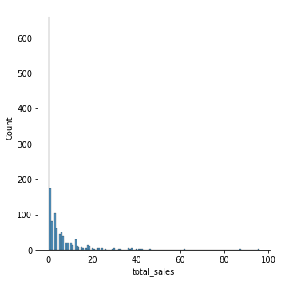

```python
sns.displot(data=web, x="total_sales")
```

#### Est-ce qu'il y a des outliers ?

```python
numericals = web.select_dtypes(include=np.number)
numericals.drop(['virtual', 'downloadable', 'rating_count', 'average_rating',
       'tax_class', 'post_author', 'post_content',
       'post_password', 'post_content_filtered', 'post_parent', 'menu_order',
       'comment_count'], axis = 1, inplace = True)

for feature in numericals:
    print(feature.upper())
    smallest = numericals[feature].min()
    print("The smallest value is", smallest)
    highest = numericals[feature].max()
    print("The highest value is", highest)
    median = numericals[feature].median()
    print("The median value is", median)
    mode =  numericals[feature].mode()
    print("The mode value is", mode)
    q1 = numericals[feature].quantile(.25)
    print("Q1 is", q1)
    q3 = numericals[feature].quantile(.75)
    print("Q3 is", q3)
    iqr = q3 - q1
    print("IQR is", iqr)
    lower_range = q1 - (1.5 * iqr)
    print("Lower range is", lower_range)
    upper_range = q3 + (1.5 * iqr)
    print("Upper range is", upper_range)
    lo = numericals.loc[numericals[feature] < lower_range]
    #No lower range outliers found
    uo = numericals.loc[numericals[feature] > upper_range]
```

```
TOTAL_SALES
The smallest value is 0.0
The highest value is 96.0
The median value is 1.0
The mode value is 0    0.0
dtype: float64
Q1 is 0.0
Q3 is 4.0
IQR is 4.0
Lower range is -6.0
Upper range is 10.0
```

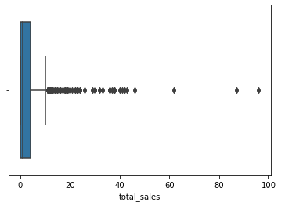

```python
sns.boxplot(data=web, x="total_sales")
```

#### Les outliers nous donne t-il des infos ?

Il y a beaucoup d'outliers et ils ont une grande variété de valeurs.

#### Quelles sont les colonnes qu'il est important de garder et de supprimer ?

Il faut garder "id_web", car c'est l'id.

Il faut garder "total_sales", car l'on en a besoins pour faire les calcul.

Il est intérressant de garder "post_name" pour avoir la dénomination.

#### Unicité de la clé primaire

L'on a vu plus haut qu'il y a 713 "post_title" et 716 "post_name".

Depuis le --> web.dropna(subset=['sku'], inplace = True), il y a désormais 711 post_title et 714 post_name.

```python
len(web["post_title"])
```

```
1428
```

```python
len(web["post_name"])
```

```
1428
```

```python
web["post_title"].value_counts()
```

```
Clos du Mont-Olivet Châteauneuf-du-Pape 2007                                          4
Domaine Hauvette IGP Alpilles Jaspe 2017                                              4
Marc Colin Et Fils Chassagne-Montrachet Blanc Les Vide-Bourses 1er Cru 2016           4
Decelle-Villa Meursault 2018                                                          2
Domaine Saint-Nicolas Fiefs Vendéens Rouge La Grande Pièce 2013                       2
Domaine Pellé Menetou Salon Blanc Les Vignes de Ratier 2018                           2
Domaine Bulliat Beaujolais Blanc 2019                                                 2
Domaine Bulliat Chiroubles Cuvée Félix 2019                                           2
Domaine Bulliat Moulin-à-Vent 2017                                                    2
David-Beaupère Juliénas La Bottière Vieilles Vignes 2018                              2
David-Beaupère Juliénas Vayolette 2017                                                2
Decelle-Villa Savigny-Lès-Beaune Blanc 2018                                           2
Bon cadeau de 25€                                                                     2
Decelle-Villa Nuits-Saint-Georges Rouge 2016                                          2
Parcé Frères Côtes du Roussillon Villages Hommage à Fernand 2017                      2
Marc Colin Et Fils Santenay Rouge 2017                                                2
Château de la Selve Coteaux de l'Ardèche Blanc Saint-Régis Blanc 2019                 2
Château de la Selve Coteaux de l'Ardèche Rouge Serre de Berty 2014                    2
Domaine Chambeyron Côtes du Rhône 2017                                                2
Domaine Chambeyron Côte Rôtie La Chavarine 2017                                       2
Domaine Chambeyron Côte Rôtie L'Angéline 2017                                         2
Domaine Chambeyron Côte Rôtie Lancement 2017                                          2
Decelle-Villa Beaune Rouge 2015                                                       2
Parcé Frères Banyuls Rimage 2018                                                      2
Domaine Chambeyron Vin de Pays des Collines Rhodaniennes Viognier 2016                2
Australie Maverick Trial Hill Riesling 2010                                           2
David-Beaupère Juliénas Les Trois Verres 2018                                         2
Argentine Alamos Catena Malbec 2017                                                   2
Argentine Mendoza Alamos Torrontes 2017                                               2
Nouvelle-Zélande Marlborough Momo Sauvignon Blanc 2018                                2
Nouvelle-Zélande Marlborough Momo Pinot Noir 2016                                     2
Nouvelle-Zélande Marlborough Kim Crawford Sauvignon Blanc 2015                        2
Liban Vallée de la Békaa Château Marsyas 2012                                         2
Australie Maverick Breechens Blend 2012                                               2
Australie Harkham Wines Old Vines 2011                                                2
La Préceptorie Maury Blanc 2015                                                       2
Chili Valdivieso Merlot 2017                                                          2
Chili Errazuriz Cabernet Sauvignon 2016                                               2
Chili De Martino Gallardia Cinsault 2017                                              2
Chili De Martino Viejas Tinajas Cinsault 2013                                         2
```

[output cut: 657 more lines]

```
Marc Colin Et Fils Saint-Aubin Blanc En Montceau 2017                                 2
Marc Colin Et Fils Chassagne-Montrachet Rouge Vieilles Vignes 2017                    2
Catherine et Claude Maréchal Bourgogne Aligoté 2018                                   2
Catherine et Claude Maréchal Ladoix Rouge Les Chaillots 2017                          2
Gilbert Picq Chablis 2017                                                             2
Catherine et Claude Maréchal Pommard La Chanière 2016                                 2
Catherine et Claude Maréchal Savigny-Lès-Beaune Rouge 2016                            2
Catherine et Claude Maréchal Volnay 2017                                              2
François Bergeret Hautes Côtes de Beaune Vieilles Vignes Rondo 2017                   2
François Bergeret Hautes Côtes de Beaune Rouge 2017                                   2
François Bergeret Hautes Côtes de Beaune Blanc 2018                                   2
Gilbert Picq Chablis Vosgros 1er Cru 2017                                             2
Gilbert Picq Chablis Vieilles Vignes 2017                                             2
Domaine Saint-Nicolas Vin de France Blanc Les Clous 2019                              2
Name: post_title, dtype: int64
```

##### "post_title"

Lorsque l'on regarde les post en doubles l'on remarque dans liaison qu'ils n'ont pas les même product_id, que veut dire que c'est 3 produits sont référencés deux product_id pour chaque vins.

Le "Clos du Mont-Olivet Châteauneuf-du-Pape 2007" est aux index 493/797/1268/1511 du dataset web et il a comme id_web 16034 et 13127-1 et comme product_id 5465 et 7247.

Le "Domaine Hauvette IGP Alpilles Jaspe 2017" est aux index 187/731/983/1497 du dataset web et il a comme id_web 15292 et 16068 et comme product_id 4288 et 6665.

Le "Marc Colin Et Fils Chassagne-Montrachet Blanc Les Vide-Bourses 1er Cru 2016" est aux index 236/514/1028/1289 du dataset web et il a comme id_web 14000 et 14828 et comme product_id 4597 et 5544.

Il y a donc 6 id_product et et id_web pour 3 produit différent.

Les post_title sont identiques.

Il a donc été possible de rentrer deux fois la même ligne, il y a donc un problème d'unicité de la clé primaire.

Il y a quand même des différence:

-les dates de post ne sont pas les mêmes.

-les post_name ne sont pas les mêmes (il y a un "les").

##### "post_name"

Il y a 714 "post_name" différent, il y avait au paravant avant le dropna, deux post_name qui n'avait que 1 lignes chacun et ayant un nan comme sku/id_web, ils ont étés supprimés.

C'est pour cela que l'on passe de 716 à 714 pour post_name.

--> pierre-jean-villa-condrieu-suspendu-2018

--> pierre-jean-villa-cote-rotie-fongeant-2017

714 étant le nombre de sku présent dans le datasetweb il n'a donc pas deux lignes ayant le même "post_name"

Il y a donc un problème d'unicité de la clé primaire car il a été possible de en premier lieu de rentrer deux fois les mêmes post_title à la seul différence que il s'agissait d'un "product" ou d'un "attachement".

L'unicité des lignes sur ce dataset est mauvaise car:

-il y a pour un même produits deux fois la même ligne (product_id compris), avec pour seules différences "tax_status", "post_excerpt", "post_type", "post_mime_type" qui sont des colonnes n'ayant pas d'informations directement liées aux produits à l'exception de "tax_status" mais qui n'est pas une infos singulière du produits en questions, étant donné que tous les produits sont taxables.

-il n' y a donc pas de garde fou empêchant de créer deux lignes donnant les mêmes informations pertinantes sur le produits.

-Il n' y a pas de garde fou permettant aux valeurs importantes d'être unique ("sku", "total_sales", ...)

#### Récap pour le dataset web

WEB (1513 lignes) contient:

```
-les noms des produits
-Les descriptions du produits
-le nombre de ventes (depuis sa mise en ligne)
```

Il est de dimension (1513, 28).

Il y a beaucoup de valeurs manquantes.

Ses valeurs sont de tous types.

En regardant les valeurs unique l'on constate pas mal d'informations:

```
-il y a des erreurs dans la colonne onsale_web de ERP.
-il y a deux lignes de produits (des produits devant être sortie du catalogue de vente) ayant des nan dans les sku de WEB.
-il y a des "doublons" dans WEB créant plusieurs sku pour un même produits.
-il y a deux fois la même ligne (le même sku apparait deux fois) pour un même produits.
```

La majorité des produits sont en dessous de 5 ventes.

La variable "total_sales" est représentée par une distribution asymétriques.

Le nombre de vente le plus haut est de 96, le plus bas est de 0 et 75% des nombres de vente sont entre 0 et 4.

Il y a des colonnes inutile.

L'unicité de la clé primaire est mauvaise, l'on a vu plus haut pourquoi.

### LIAISON

```
-Les product_id
-Les sku/id_web
```

L'analyse de LIAISON "n'est pas à faire" dans le sens où ce qu'il y a à relevé l'a été dans l'analyse des dataset ERP et WEB.

## Les différentes demandes:

1. J’ai besoin que tu rapproches deux exports : un export de l’ERP contenant les références produit, leur prix de vente et leur état de stock, et un export d’une table de l’outil de CMS contenant les informations des produits commercialisés en ligne (nom, description, nombre de ventes...).
1. Une fois le rapprochement effectué, je souhaiterais avoir le chiffre d’affaires par produit, ainsi que le total du chiffre d’affaires réalisé en ligne.
1. Pour finir, je me demande s’il n’y a pas eu des erreurs de saisie dans certains prix des produits. J'aimerais que tu effectues une analyse sur cette variable afin de détecter d’éventuelles valeurs aberrantes, de les lister et d’en faire une représentation graphique pour plus de lisibilité.

Il y a certaines modifications à faire avant rapprochement:

```
WEB
-Il y a 85 lignes de nan dans WEB (DEJA RETIREES VOIR PLUS HAUT !).
-Il y a les 714 lignes "attachement".
-Il y les deux nan dans la colonne sku dans WEB index 470 et 471 (DEJA RETIREES VOIR PLUS HAUT !).

LIAISON
-Il faut retirer les nan du fichiers (DEJA RETIREES VOIR PLUS HAUT !).
```

Il y a certaines modifications à faire après rapprochement:

```
DF
-Il y les 3 onsale_web incoorect à modifier.
```

## *1. Rapprochement*

Pour le rapprochement j'utilise le left car ayant 825 product_id (onsale_web 0 et 1 confondue), et cherchant à rapporcher les valeurs onsale_web = 1 avec ses sku/id_web correspondant je dois faire s'insérer/matcher web dans erp et pas l'inverse.

Pour la jointure entre erp et liaison la correspondance ce fait de la même manière.

```python
web = web[web.post_type != "attachment"]
```

```python
df = erp.merge(liaison, how='left', on='product_id')
```

```python
web.rename(columns = {'sku':'id_web'}, inplace = True)
```

```python
df = df.merge(web, how="left", on="id_web")
```

```python
df.loc[(df['onsale_web'] == 1) & (df['id_web'].isnull()), 'onsale_web'] = 0
```

```python
df['onsale_web'].loc[[487]]
```

```
487    0
Name: onsale_web, dtype: int64
```

```python
df.info()
```

```
<class 'pandas.core.frame.DataFrame'>
Int64Index: 825 entries, 0 to 824
Data columns (total 33 columns):
 #   Column                 Non-Null Count  Dtype
---  ------                 --------------  -----
 0   product_id             825 non-null    int64
 1   onsale_web             825 non-null    int64
 2   price                  825 non-null    float64
 3   stock_quantity         825 non-null    int64
 4   stock_status           825 non-null    object
 5   id_web                 734 non-null    object
 6   virtual                714 non-null    float64
 7   downloadable           714 non-null    float64
 8   rating_count           714 non-null    float64
 9   average_rating         714 non-null    float64
```

[output cut: 25 more lines]

J'ai bien mes 825 lignes (onsale_web 0 et 1) et mes 714 sku/id_web + 20 (product_id correspondent à des sku/id_web qui n'existe pas dans web.).

J'ai donc une jointure conforme car mes valeurs de web ce sont bien insérées dans erp.

```python
liaison
```

|  | product_id | id_web |
| --- | --- | --- |
| 0 | 3847 | 15298 |
| 1 | 3849 | 15296 |
| 2 | 3850 | 15300 |
| 3 | 4032 | 19814 |
| 4 | 4039 | 19815 |
| 5 | 4040 | 15303 |
| 6 | 4041 | 14975 |
| 7 | 4042 | 16042 |
| 8 | 4043 | 14980 |
| 9 | 4045 | 16041 |
| 10 | 4046 | 15269 |
| 11 | 4047 | 14977 |
| 12 | 4048 | 16044 |
| 13 | 4049 | 16043 |
| 14 | 4050 | 16449 |
| 15 | 4051 | 16045 |
| 16 | 4052 | 16030 |
| 17 | 4053 | 13127 |
| 18 | 4054 | 19816 |
| 20 | 4056 | 16029 |
| 21 | 4057 | 16039 |
| 22 | 4058 | 16318 |
| 23 | 4059 | 16275 |
| 24 | 4060 | 16498 |
| 25 | 4062 | 16320 |
| 26 | 4063 | 16319 |
| 27 | 4064 | 15966 |
| 28 | 4065 | 15022 |
| 29 | 4066 | 15967 |
| 30 | 4067 | 15490 |

[output cut: 704 more lines]

## *2. Calcul du chiffre d’affaires par produit + le total du chiffre d’affaires réalisé en ligne.*

*ATTENTION IL NE PEUT Y AVOIR QUE DES PRODUITS EN LIGNES CAR NOUS NAVONS PAS DE COLONNE DE QUANTITEES VENDUE POUR LES PRODUITS VENDUES HORS LIGNE.*

```python
df["ca_product_online"] = df.loc[df['onsale_web'] == 1, 'price'] * df.loc[df['onsale_web'] == 1, 'total_sales']

df.head(5)
```

|  | product_id | onsale_web | price | stock_quantity | stock_status | id_web | virtual | downloadable | rating_count | average_rating | ... | post_modified | post_modified_gmt | post_content_filtered | post_parent | guid | menu_order | post_type | post_mime_type | comment_count | ca_product_online |
| --- | --- | --- | --- | --- | --- | --- | --- | --- | --- | --- | --- | --- | --- | --- | --- | --- | --- | --- | --- | --- | --- |
| 0 | 3847 | 1 | 24.2 | 0 | outofstock | 15298 | 0.0 | 0.0 | 0.0 | 0.0 | ... | 2019-12-30 09:30:29 | 2019-12-30 08:30:29 | NaN | 0.0 | https://www.bottle-neck.fr/?post_type=product&... | 0.0 | product | NaN | 0.0 | 145.2 |
| 1 | 3849 | 1 | 34.3 | 0 | outofstock | 15296 | 0.0 | 0.0 | 0.0 | 0.0 | ... | 2019-12-21 09:00:17 | 2019-12-21 08:00:17 | NaN | 0.0 | https://www.bottle-neck.fr/?post_type=product&... | 0.0 | product | NaN | 0.0 | 0.0 |
| 2 | 3850 | 1 | 20.8 | 0 | outofstock | 15300 | 0.0 | 0.0 | 0.0 | 0.0 | ... | 2020-06-26 18:15:03 | 2020-06-26 16:15:03 | NaN | 0.0 | https://www.bottle-neck.fr/?post_type=product&... | 0.0 | product | NaN | 0.0 | 0.0 |
| 3 | 4032 | 1 | 14.1 | 0 | outofstock | 19814 | 0.0 | 0.0 | 0.0 | 0.0 | ... | 2020-01-04 16:36:01 | 2020-01-04 15:36:01 | NaN | 0.0 | https://www.bottle-neck.fr/?post_type=product&... | 0.0 | product | NaN | 0.0 | 42.3 |
| 4 | 4039 | 1 | 46.0 | 0 | outofstock | 19815 | 0.0 | 0.0 | 0.0 | 0.0 | ... | 2020-01-04 16:36:10 | 2020-01-04 15:36:10 | NaN | 0.0 | https://www.bottle-neck.fr/?post_type=product&... | 0.0 | product | NaN | 0.0 | 0.0 |

5 rows × 34 columns

```python
total = df["ca_product_online"].sum()
print("Le total du chiffre d’affaires réalisé en ligne est de", total, "€")
```

```
Le total du chiffre d’affaires réalisé en ligne est de 70568.6 €
```

## *3. Faire une analyse sur la variable "prix", afin de détecter d’éventuelles valeurs aberrantes, de les lister et d’en faire une représentation graphique pour plus de lisibilité.*

```python
numericals = df.select_dtypes(include=np.number)

numericals.drop(['product_id', 'onsale_web', 'stock_quantity', 'total_sales', 'ca_product_online'], axis = 1, inplace = True)
```

### Distribution des données

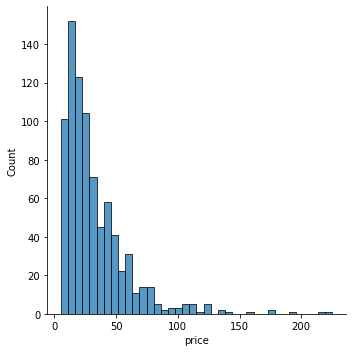

```python
sns.displot(data=numericals, x="price")
```

Comme on peut le voir sur le graphique, les données sont très asymétriques.

On voit qu'elle sont en majoritée sur la partie gauche du graphique.

On peut dire qu'environ 90% de nos données sont comprises entre 5 et 100€.

### Recherche des outliers via l'IQR

```python
for feature in numericals:
    print(feature.upper())
    smallest = numericals[feature].min()
    print("The smallest value is", smallest)
    highest = numericals[feature].max()
    print("The highest value is", highest)
    median = numericals[feature].median()
    print("The median value is", median)
    mode =  numericals[feature].mode()
    print("The mode value is", mode)
    q1 = numericals[feature].quantile(.25)
    print("Q1 is", q1)
    q3 = numericals[feature].quantile(.75)
    print("Q3 is", q3)
    iqr = q3 - q1
    print("IQR is", iqr)
    lower_range = q1 - (1.5 * iqr)
    print("Lower range is", lower_range)
    upper_range = q3 + (1.5 * iqr)
    print("Upper range is", upper_range)
    lo = numericals.loc[numericals[feature] < lower_range]
    #No lower range outliers found
    uo = numericals.loc[numericals[feature] > upper_range]
```

```
PRICE
The smallest value is 5.2
The highest value is 225.0
The median value is 24.4
The mode value is 0    45.0
dtype: float64
Q1 is 14.6
Q3 is 42.0
IQR is 27.4
Lower range is -26.499999999999993
Upper range is 83.1
VIRTUAL
The smallest value is 0.0
The highest value is 0.0
The median value is 0.0
The mode value is 0    0.0
dtype: float64
Q1 is 0.0
Q3 is 0.0
IQR is 0.0
Lower range is 0.0
Upper range is 0.0
DOWNLOADABLE
The smallest value is 0.0
The highest value is 0.0
The median value is 0.0
The mode value is 0    0.0
dtype: float64
Q1 is 0.0
Q3 is 0.0
IQR is 0.0
Lower range is 0.0
Upper range is 0.0
RATING_COUNT
The smallest value is 0.0
The highest value is 0.0
The median value is 0.0
The mode value is 0    0.0
dtype: float64
Q1 is 0.0
```

[output cut: 84 more lines]

```
Q3 is 0.0
IQR is 0.0
Lower range is 0.0
Upper range is 0.0
COMMENT_COUNT
The smallest value is 0.0
The highest value is 0.0
The median value is 0.0
The mode value is 0    0.0
dtype: float64
Q1 is 0.0
Q3 is 0.0
IQR is 0.0
Lower range is 0.0
Upper range is 0.0
```

### Distribution de mes données via le boxplot

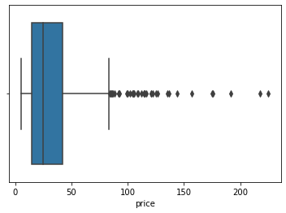

```python
sns.boxplot(x=numericals["price"])
```

### Mise en lumière des outliers via un scatterplot

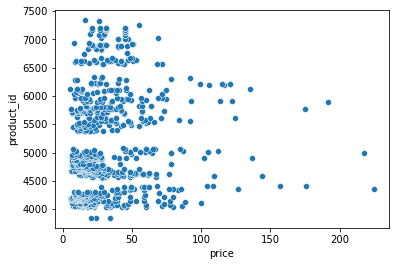

```python
sns.scatterplot(data=df, x="price", y="product_id")
```

**POURQUOI J'AI UTILISER CES TYPES DE MESURES (IQR / BOXPLOT)**

J'ai une distribution skewed (asymétrique). En effet mes données sont concentrées sur la gauche de la gamme de valeur que j'ai.

```
 BOXPLOT
 Mes données sont asymétrique donc je ne peux pas utiliser de techniques impliquants la moyenne pour rechercher mes outliers.
 Car le fait d'avoir des données asymétrique, fait perdre à la moyenne sa capacité de déterminer la tendence centrale des données !!!
 Les données asymétrique éloigne la moyenne la valeur du milieu, exemple si j'ai le jeu de données suivant --> 1, 2, 3, 4, 5 la moyenne est 3, mais si j'ai un jeu de données comme ça --> 1, 2, 3, 100 la moyenne est 26.5.
 L'on voit bien avec les deux exemples plus haut que la moyenne est impactée par les outliers elle prends en compte tous les points même les outliers.
 Il faut donc une méthode plus robuste, utilisant la médiane car elle va éliminer l'influence des outliers en retournant le nombre au centre du data set et donc en ayant la la tendence centrale des données il est possible de détécter ce qui s'en éloignent.

 IQR
 La mesure de dispertion decrit la variabilité des données.
 Les "interquartiles ranges" seront de meilleurs mesure de dispertion car ils ne sont pas impactés par les outliers ou bien une distribution skewed.
 Le "range" est la différence entre la plus haut valeur et la plus basse. Il permet de connaitre ses valeurs extrêmes permettant de détécter des erreurs, exemple un jeu de données sur les âges d'enfants dans une école avec en une valeur max de 123 ans.
 Les quartiles ne sont pas sensible au outliers comme la deviation standards. Ils cassent les données en quart de la même manière que la médiane casse les données à la moitiée.
 D'où le fait qu'ils ne soit pas sensible au outliers.
 Les interquartiles nous donnent la différence le 1er et 3ème quartiles, ce qui nous donne des informations sur la gamme de la la moitié médiane.
```

Donc si les données sont skewed ou ont des outliers, il vaut mieux utiliser la médiane pour la central tendency et l'IQR pour la mesure de dispertion des données.

### *Ma conclusion sur les valeurs aberrantes.*

IL S'AGIT DE VINS, ET LES VINS ONT DES GAMMES DE PRIX TRES VARIES. LES PRIX PEUVENT ALLER DE ENVIRON 2€ A DES PRIX INCROYABLES. TOUS DEPEND DE LA BOUTEILLE, IL FAUDRAIT BIEN CONNAITRE LES VINS POUR SAVOIR SI IL Y A DES PRIX FAUX.

DE PLUS IL N'Y A PAS DE VALEURS NEGATIVES OU BIEN DES CHIFFRES AFFOLANTS COMME PAR EXEMPLE 1 000 000 000€. JE NE VOIS DONC PAS DE VALEURS ABERRANTES.

CERTAINES LIGNES N'ONT PAS CERTAINES INFOS, CE QUI EST NORMAL CAR LES INFOS SONT POUR LES PRODUITS COMMERCIALISES EN LIGNES, ET CES LIGNES CORRESPONDENT A DES PRODUITS NON COMMERCIALISES EN LIGNE.